# Analiza Discriminantă Liniară (ADL)

ADL este o metodă statistică *supervizată* (predictivă), diferită de cele anterioare.

Obiectivul este de a construi un model decizional (o regulă matematică) care să poată identifica automat *Segmentul* (`variabila_dependenta`) din care face parte o mașină, folosind doar specificațiile sale tehnice *(Putere, Dimensiuni, Consum etc.)*. Modelul caută combinația optimă de variabile care separă cel mai bine aceste segmente. **Pregătirea Datelor:** În această etapă, utilizăm un set de date deja procesat care conține diviziunea clară a mașinilor necesară pentru validare. Încărcăm acest fișier pentru a pregăti terenul pentru antrenarea și testarea modelului. Modul în care a fost procesat setul de date inițial este următorul:

- s-a adăugat o coloană numită "Partition" care conține una din două constante: *Antrenament*, *Test*
- s-a folosit o funcție *shuffle* care amestecă etichetele observațiilor din coloana "Partition"
- o metoda alternativă este utilizarea bibliotecii *model_selection* cu funcția *train_test_split* care împarte datele

```python
import numpy as np
import pandas as pd
from sklearn.discriminant_analysis import LinearDiscriminantAnalysis
from sklearn.metrics import confusion_matrix
import matplotlib.pyplot as plt
import seaborn as sb
#from sklearn.model_selection import train_test_split

#x_train,y_train,x_test,y_test=train_test_split(x,y,0.3,random_state=1,stratify=y)
masini=pd.read_csv('SET DE DATE/masini_proiect_final_partitionat.csv',index_col=(0,1,2))
masini.head()
```

| ID | Company | Model | Segment | Fuel | Power(HP) | Torque(Nm) | Displacement | Length | Width | Height | Wheelbase | Cargo Volume | Unladen Weight | Top Speed | Acceleration 0-62 Mph (0-100 kph) | Combined mpg | Fuel capacity | Partition |
| --- | --- | --- | --- | --- | --- | --- | --- | --- | --- | --- | --- | --- | --- | --- | --- | --- | --- | --- |
| 1 | BMW | BMW 1 Series (F40) (2019-Present) | Compact | Diesel | 150.0 | 350.0 | 1995.0 | 170.0 | 70.8 | 56.5 | 105.1 | 13.4 | 3252.0 | 135.0 | 8.5 | 53.5 | 13.2 | Antrenament |
| 2 | KIA | 2012 Kia cee'd | Compact | Gasoline | 101.0 | 137.0 | 1396.0 | 169.7 | 70.1 | 57.9 | 104.3 | 13.4 | 2773.0 | 113.0 | 12.8 | 39.2 | 14.0 | Antrenament |
| 3 | OPEL | OPEL Astra GTC (2011-Present) | Compact | Gasoline | 170.0 | 260.0 | 1598.0 | 175.8 | 72.4 | 58.3 | 106.1 | 13.1 | 3314.0 | 136.0 | 8.6 | 38.6 | 14.8 | Antrenament |
| 4 | PROTON | PROTON Preve (2011-Present) | Compact | Gasoline | 109.0 | 150.0 | 1597.0 | 178.9 | 70.3 | 60.0 | 104.3 | 17.9 | 2921.0 | 106.0 | 12.5 | 29.4 | 13.2 | Antrenament |
| 5 | ALFA ROMEO | ALFA ROMEO Giulietta (2016-Present) | Compact | Diesel | 120.0 | 320.0 | 1598.0 | 171.3 | 70.8 | 57.7 | 103.7 | 12.4 | 3053.0 | 121.0 | 10.0 | 60.3 | 15.9 | Antrenament |

## Structurarea Datelor

Odată încărcat setul partiționat, il separăm în două componente logice necesare procesului de învățare supervizată:

1. **Variabile Independente (Input):** Cei 13 parametri tehnici (motori, dimensiuni etc.) pe care modelul îi va analiza.
2. **Variabila Dependentă (Target):** *Segmentul* (clasa mașinii), adică rezultatul pe care încercăm să-l prezicem.

Separăm apoi observațiile în **train (x_train, y_train)** (pentru construirea modelului) și **test (x_test)** (pentru validarea sa).

```python
masini_train=masini.loc[masini['Partition']=='Antrenament']
masini_test=masini.loc[masini['Partition']=='Test']

variabile_independente=masini.columns[2:15].tolist()
variabila_dependenta='Segment'

x_train=masini_train[variabile_independente].values
y_train=masini_train[variabila_dependenta].values

x_test=masini_test[variabile_independente].values
observatii=masini_test.index
```

## Functie de calcul acuratete si matrice de confuzie

Funcția calculează acuratețea seturilor de date. Primește ceva ce știm că e real (y_true), ceva ce am prezis (y_pred) și clasele, adică grupele după care calculăm.

- *matricea de confuzie* reprezintă o matrice unde etichetele rândurilor coincid cu cele ale coloanelor, și arată câte observații au fost prezise corect și câte eronate.
- *ag* reprezintă acuratețea globală a modelului calculând cât la sută a reușit să prezică din totalul de observații
- *a_within_g* reprezintă acuratețea în interiorul fiecărei grupe, arătând, pentru fiecare grupă cât la sută din observații a fost prezis corect
- *am* reprezintă acuratețea medie dintre grupe **Important** de precizat este că, pentru a face predicții pe un set de date ( cel de test), trebuie mai întâi să calculăm cât de bun este modelul creat pe datele de antrenament pentru că aici avem avantajul de a ști rezultatul adevărat. Spre exemplu, să luăm observația BMW F80. Dorim să găsim dacă se încadrează la segmentul de mașină de lux sau mașină sport. Dacă modelul ar prezice a doăa variantă, iar reală este prima, am știi că modelul a greșit. Pe datele de test vom lua în considerare acuratețea dată de model. Cu cât acuratețea e mai mare, cu atât putem avea mai mult încredere că modelul nu are erori de predicție pe datele de test.

```python
def calculeaza_acuratate(y_true,y_pred,grupe):
    matrice_confuzie=confusion_matrix(y_true,y_pred,labels=grupe)
    ag=np.round(np.diagonal(matrice_confuzie).sum()*100/np.sum(matrice_confuzie),3)
    a_within_g=np.round(np.diagonal(matrice_confuzie)*100/np.sum(matrice_confuzie,axis=1),3)
    am=np.mean(a_within_g)
    return matrice_confuzie,ag,a_within_g,am
```

## Crearea modelului

```python
model_lda=LinearDiscriminantAnalysis()
model_lda.fit(x_train,y_train)
grupe=model_lda.classes_
```

## Testarea

```python
y_train_prezis=model_lda.predict(x_train)
y_test_prezis=model_lda.predict(x_test)

matrice_confuzie,acuratete_globala, acuratate_in_interiorul_grupelor,acuratete_medie=calculeaza_acuratate(y_train,y_train_prezis,grupe)

print('Acuratetea globala: ',acuratete_globala)
print('Acurataetea intre grupuri: ',acuratate_in_interiorul_grupelor)
print('Acuratetea medie: ',acuratete_medie)
```

```
Acuratetea globala:  56.767
Acurataetea intre grupuri:  [77.481 47.059 69.444 73.729 53.846 62.5   41.935 44.444 56.818 69.565
 55.882 46.739 44.444 52.5   48.387 72.222 25.    42.857 44.444 15.
  0.    22.727  0.   ]
Acuratetea medie:  46.39230434782609
```

**Acuratețea Globală (56.77%):** Modelul reușește să identifice corect segmentul mașinii în peste jumătate din cazuri. Deși poate părea mic, pentru un set de date complex cu multe clase (peste 20, după cum arată lista), rezultatul este **semnificativ mai bun decât ghicitul aleatoriu** (care ar fi sub 5%).

**Variația pe Segmente:** Observăm discrepanțe mari în recunoaștere:

- **Segmente "Ușoare":** Unele au acuratețe de **77%, 73%**, fiind foarte distincte (probabil SUV-uri mari sau Supercar-uri).
- **Segmente "Confuze":** Altele au valori foarte mici (**0%, 15%**), semn că modelul le confundă frecvent cu categorii similare (ex: diferența dintre *Compact* și *Coupe Cabrio* poate fi prea subtilă pentru analiză).

## Realitatea vs Predicție

```python
df1=pd.DataFrame({
    variabila_dependenta:y_train,
    'Predictia modelului':y_train_prezis
},index=masini_train.index)
df1.head(30)
```

| ID | Company | Model | Segment | Predictia modelului |
| --- | --- | --- | --- | --- |
| 1 | BMW | BMW 1 Series (F40) (2019-Present) | Compact | Compact |
| 2 | KIA | 2012 Kia cee'd | Compact | Compact |
| 3 | OPEL | OPEL Astra GTC (2011-Present) | Compact | Compact |
| 4 | PROTON | PROTON Preve (2011-Present) | Compact | Compact |
| 5 | ALFA ROMEO | ALFA ROMEO Giulietta (2016-Present) | Compact | Compact |
| 6 | BMW | BMW 1 Series 3 doors (F20) LCI (2017-Present) | Compact | Compact |
| 7 | SEAT | SEAT Ibiza 5 doors (2017-Present) | Compact | Crossover |
| 8 | ALFA ROMEO | ALFA ROMEO Giulietta (2016-Present) | Compact | Compact |
| 9 | OPEL | OPEL Corsa 3 Doors (2014-Present) | Compact | Compact |
| 10 | OPEL | OPEL Corsa 3 Doors (2014-Present) | Compact | Compact |
| 11 | OPEL | OPEL Astra GTC (2011-Present) | Compact | Compact |
| 12 | AUDI | AUDI A3 Cabriolet (2016-Present) | Compact | Compact |
| 13 | ALFA ROMEO | ALFA ROMEO Giulia (2022-Present) | Compact | Medium |
| 14 | DATSUN | DATSUN on-Do (2014-Present) | Compact | Compact |
| 15 | MINI | MINI Clubman (2019-Present) | Compact | Compact |
| 16 | ALFA ROMEO | ALFA ROMEO Giulietta (2016-Present) | Compact | Compact |
| 17 | SKODA | SKODA Rapid Spaceback (2013-Present) | Compact | Compact |
| 18 | MAZDA | 2019 Mazda 3/Axela Hatchback | Compact | Compact |
| 19 | AUDI | AUDI A3 Cabriolet (2016-Present) | Compact | Coupe Cabrio |
| 20 | SUZUKI | SUZUKI Baleno (2016-Present) | Compact | Compact |
| 21 | SKODA | 2019 Skoda Scala | Compact | Compact |
| 22 | AUDI | AUDI A3 Sportback (2020-Present) | Compact | Compact |
| 23 | OPEL | OPEL Astra Sport Sedan (2012-Present) | Compact | Compact |
| 24 | OPEL | OPEL Corsa 3 Doors (2014-Present) | Compact | Compact |
| 25 | FORD | FORD Focus Active Wagon (2021-Present) | Compact | Compact |
| 26 | NISSAN | NISSAN Primera Sedan (2002-Present) | Compact | Compact |
| 27 | SKODA | SKODA Superb (2019-Present) | Compact | Medium |
| 28 | BMW | BMW 1 Series 3 doors (F20) LCI (2017-Present) | Compact | Compact |
| 29 | OPEL | 2020 Opel Corsa | Compact | Crossover |
| 30 | MAZDA | 2019 Mazda 3/Axela Hatchback | Compact | Compact |

Acest tabel detaliază rezultatele punctuale :

- **Succese:** Modelul identifică corect majoritatea modelelor standard (*BMW Seria 1, Kia cee'd, Opel Astra*), clasificându-le corect drept "Compact".
- **Erori Notabile:**
  - *SEAT Ibiza:* Clasificat greșit ca "Crossover" (probabil din cauza dimensiunilor atipice sau a gărzii la sol).
  - *Alfa Romeo Giulia:* Clasificat ca "Medium" (o confuzie logică, Giulia fiind la limita superioară a clasei compacte/medii).
  - *Audi A3 Cabriolet:* Clasificat ca "Coupe Cabrio". Aceasta este de fapt o *eroare "bună"*, deoarece mașina chiar este un cabriolet compact, iar modelul a fost mai specific decât eticheta originală generică.

## Predicțiile pe datele de test

```python
df2=pd.DataFrame({
    'Predictia modelului':y_test_prezis
},index=masini_test.index)
df2.head(30)
```

| ID | Company | Model | Predictia modelului |
| --- | --- | --- | --- |
| 263 | QOROS | QOROS 3 Hatchbach (2014-Present) | Compact |
| 264 | ALFA ROMEO | ALFA ROMEO Giulietta (2016-Present) | Compact |
| 265 | OPEL | OPEL Astra Sport Sedan (2012-Present) | Compact |
| 266 | ALFA ROMEO | ALFA ROMEO Giulietta (2016-Present) | Compact |
| 267 | BMW | BMW 1 Series 3 doors (F20) LCI (2017-Present) | Compact |
| 268 | MAZDA | MAZDA 3 / Axela Sedan (2018-Present) | Compact |
| 269 | SKODA | SKODA Superb (2019-Present) | Medium |
| 270 | MERCEDES BENZ | MERCEDES BENZ A-Class Sedan (V177) (2018-Present) | Compact |
| 271 | Mercedes-AMG | Mercedes-AMG C43 (2022-Present) | Medium Premium |
| 272 | NISSAN | NISSAN Pulsar (2014-Present) | Compact |
| 273 | AUDI | AUDI S3 Sportback (2020-Present) | Compact |
| 274 | RENAULT | RENAULT Captur (2019-Present) | Crossover |
| 275 | BMW | BMW 2 Series Gran Tourer (F46) (2018-Present) | Crossover |
| 276 | BMW | BMW 2 Series Gran Tourer (F46) (2018-Present) | Medium MPV |
| 277 | KIA | 2019 Kia ProCeed | Compact |
| 278 | KIA | KIA cee'd (2015-Present) | Compact |
| 279 | AUDI | AUDI RS 3 Sportback (2021-Present) | Roadster & Convertible |
| 280 | RENAULT | RENAULT Megane Coupe - Cabrio (2014-Present) | Compact |
| 281 | KIA | 2012 Kia cee'd | Compact |
| 282 | FORD | FORD Focus Active Wagon (2021-Present) | Compact |
| 283 | TOYOTA | TOYOTA AURIS (2018-Present) | Compact |
| 284 | QOROS | QOROS 3 Sedan (2013-Present) | Compact |
| 285 | HOLDEN | HOLDEN Cruze (2008-Present) | Compact |
| 286 | AUDI | AUDI A3 Sportback (2020-Present) | Compact |
| 287 | MERCEDES BENZ | 2019 Mercedes-Benz CLA Shooting Brake | Entry Premium |
| 288 | KIA | 2012 Kia cee'd | Compact |
| 289 | SKODA | SKODA Superb (2019-Present) | Medium |
| 290 | SUZUKI | SUZUKI Baleno (2016-Present) | Compact |
| 291 | BMW | BMW 2 Series Gran Tourer (F46) (2018-Present) | Crossover |
| 292 | BMW | BMW 2 Series Gran Tourer (F46) (2018-Present) | Medium MPV |

Comparând predicțiile cu realitatea pe eșantionul afișat, putem trage câteva concluzii foarte interesante despre comportamentul modelului:

1. **Compactele Clasice:** Modelul excelează la identificarea hatchback-urilor standard. Modele precum *BMW Seria 1, Mazda 3, Opel Astra* sau *Kia cee'd* sunt clasificate corect și consistent ca "Compact". Asta arată că nucleul clasei este bine definit matematic.
2. **Distingerea Mărimii:**
   - *Skoda Superb:* Predicția este "Medium". Acesta este un rezultat excelent! Superb este o mașină de clasă medie/mare, mult mai spațioasă decât o compactă (Octavia/Scala), iar modelul a sesizat corect diferența de gabarit.
3. **Cross-over și MPV:**
   - *Renault Captur:* Clasificat corect ca "Crossover". Modelul a reușit să distingă Captur-ul (care e un SUV mic) de Clio/Megane, probabil datorită înălțimii sau proporțiilor diferite.
   - *BMW Seria 2 Gran Tourer:* Apare clasificat când ca "Crossover", când ca "Medium MPV". Deși oscilează, ambele predicții sunt corecte funcțional: este un monovolum (MPV) care se suprapune ca utilizare cu crossoverele. Important e că NU l-a numit "Compact" simplu.
4. **Confuzii de Performanță:**
   - *Audi RS3 Sportback:* Clasificat ca "Roadster & Convertible". Aceasta este o eroare interesantă! RS3 este un "Hot Hatch" extrem de rapid. Probabil că specificațiile sale (putere imensă, accelerație rapidă) seamănă atât de mult cu cele ale mașinilor sport decapotabile din setul de antrenare, încât modelul l-a etichetat greșit bazându-se pe performanță, ignorând forma caroseriei.

## Reducem dimensionalitatea variabilelor

Similar cu ACP (care căuta varianța maximă), ADL calculează noi axe care maximizează distanța dintre grupuri.

- Transformăm datele de antrenament (*x_train*) în coordonate noi (*z_train*), numite *scoruri discriminante*. Acestea repoziționează fiecare mașină într-un spațiu optimizat pentru separarea claselor.
- Calculăm și transformăm *centroizii* (*means*) fiecărui segment. Aceștia reprezintă "mașina ideală" sau centrul de greutate pentru fiecare categorie (ex: unde se află "media" tuturor SUV-urilor), permițând vizualizarea distanței dintre segmente.

```python
z_train=model_lda.transform(x_train)
means=model_lda.means_
z_means=model_lda.transform(means)
```

## Grafice

### Graficul primelor două noi componente găsite la reducerea dimensionalității

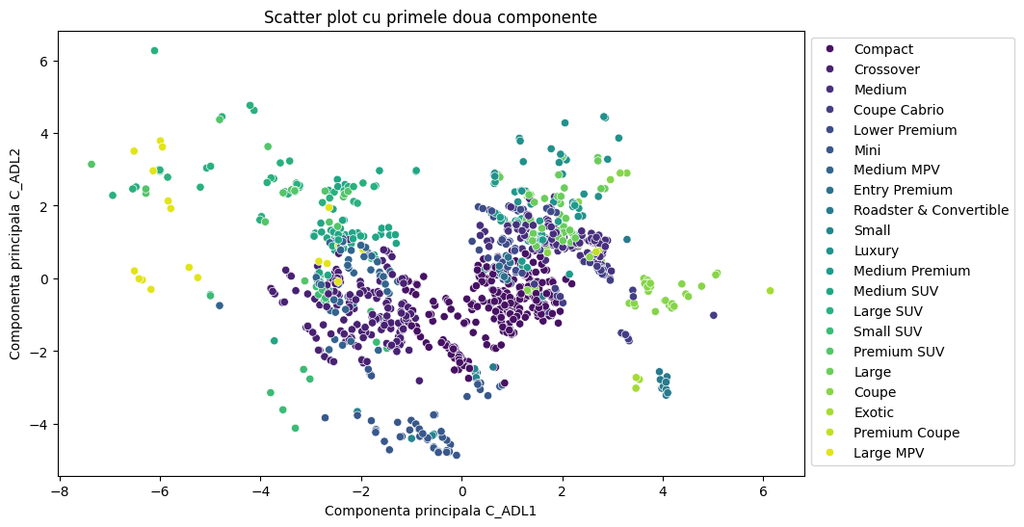

```python
plt.figure(figsize=(10,6))
plt.title('Scatter plot cu primele doua componente')
plt.xlabel('Componenta principala C_ADL1')
plt.ylabel('Componenta principala C_ADL2')
ax=sb.scatterplot(x=z_train[:,0],y=z_train[:,1],hue=y_train_prezis,palette='viridis')
sb.move_legend(ax, "upper left", bbox_to_anchor=(1, 1));
```

### Graficul distributiei grupelor pe prima axa C_ADL1

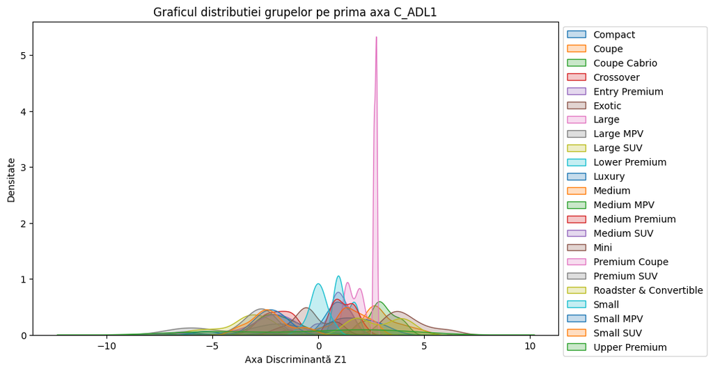

```python
plt.figure(figsize=(10,6))
bx=plt.gca()
plt.title('Graficul distributiei grupelor pe prima axa C_ADL1')
grupe_unice=np.unique(y_train)
for g in grupe_unice:
    date_axa1 = z_train[y_train == g]
    valori = date_axa1[:, 0]
    sb.kdeplot(valori,fill=True,label=str(g))
plt.legend()
sb.move_legend(bx, "upper left", bbox_to_anchor=(1, 1))
plt.xlabel('Axa Discriminantă Z1')
plt.ylabel('Densitate');
```

### Graficul matricei de confuzie

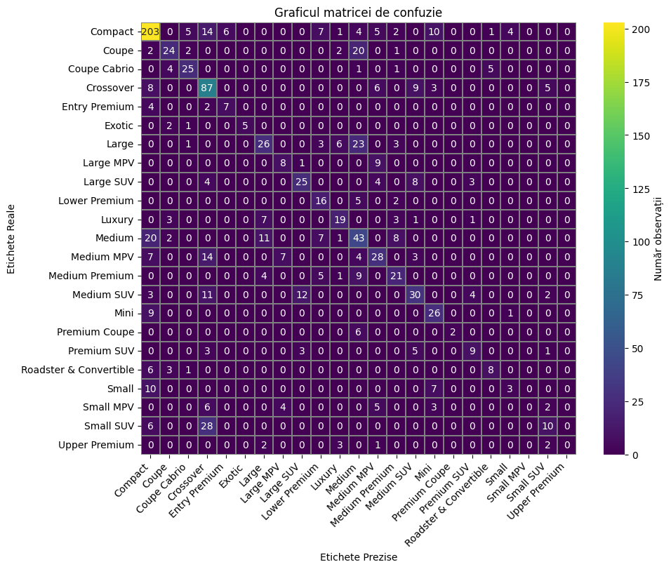

```python
plt.figure(figsize=(10,8))
plt.title('Graficul matricei de confuzie')
sb.heatmap(matrice_confuzie,
           cmap='viridis',
           annot=True,
           fmt='d',
           xticklabels=grupe_unice,
           yticklabels=grupe_unice,
           linewidths=0.3,
           linecolor='gray',
           cbar_kws={'label': 'Număr observații'})
plt.xticks(rotation=45, ha='right')
plt.xlabel('Etichete Prezise')
plt.ylabel('Etichete Reale');
```

### Reprezentarea vizuala a centroizilor si a scorurilor obtinute din reducerea dimensionalitatii

```
Numarul de axe este 13
```

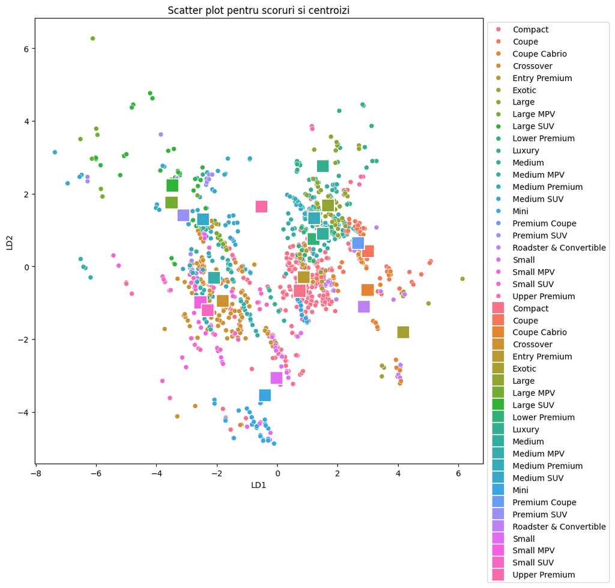

```python
n_axe=min(len(variabile_independente),len(grupe)-1)
print(f"Numarul de axe este {n_axe}")   #13

plt.figure(figsize=(10,10))
cx=plt.gca()
plt.title('Scatter plot pentru scoruri si centroizi')
sb.scatterplot(x=z_train[:,0],y=z_train[:,1],hue=y_train,hue_order=grupe)
sb.scatterplot(x=z_means[:,0],y=z_means[:,1],hue=grupe,marker='s',s=255)
sb.move_legend(cx, "upper left", bbox_to_anchor=(1, 1))
plt.xlabel('LD1')
plt.ylabel('LD2');
```